# Testing Independence between Networks and Attributes

# Block Dependent Model

For each block $i = 1,... , B:$

$(X_{i,1}, Y_{i,1}), (X_{i,2}, Y_{i,2}) , ... , (X_{i, n_{i}}, Y_{i, n_{i}}) \overset{i.i.d}{\sim} N \left( \begin{bmatrix} 0 \\ 0 \end{bmatrix}, \begin{bmatrix}1 & \rho_{i} \\ \rho_{i} & 1 \end{bmatrix} \right)$

Let $(\textbf{X}, \textbf{Y}) = \{ (X_{i,j}, Y_{i,j}) ; j = 1,..., n_{i}, i = 1,...,B \}$ ; $N = \sum\limits_{i=1}^{B} n_{i}.$ Same as before $T_{ij}$ is a Bernoulli random variable of having an edge between node $i$ and node $j$.

$\log \left( \frac{P\big( T_{ij} \big) }{1 - P\big( T_{ij} \big) } \big| X_i, X_j \right) = f \big( | X_i - X_j | \big)$

$f\big( |X_i - X_j| \big) = \left\{ \begin{array}{cc} |X_i - X_j| & \max(0.01, |X_i - X_j| ) < 0.10 \\ -20 |X_{i} - X_{j}| & \mbox{ o.w.} \end{array} \right.$

1. $B = 2;$ $\rho = (0.0, 0.1)$; ratio = (1,1); $n=300$ ; $M=500$

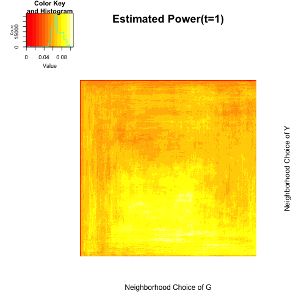

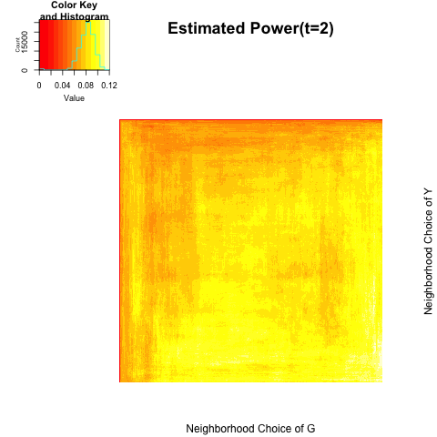

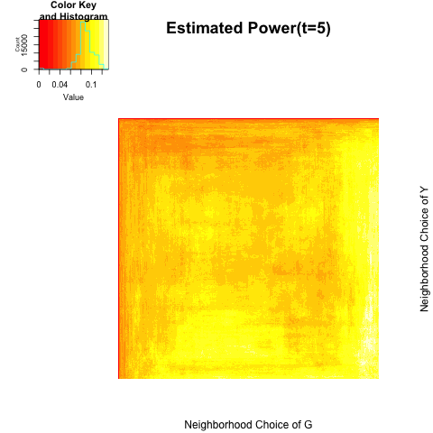

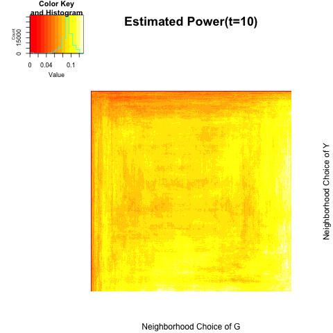

|  | t=1 | t=2 | t=5 | t=10 |
| --- | --- | --- | --- | --- |
| global test | 0.068 | 0.098 | 0.110 | 0.116 |
| local optimal | 0.106 | 0.120 | 0.132 | 0.130 |

2. $B =2;$ $\rho = (0.1, 0.2);$ raio = (1,1); $n=300$; $M=500$

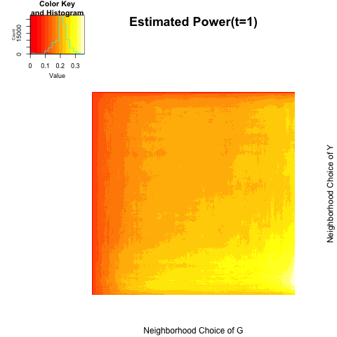

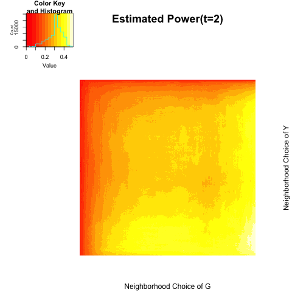

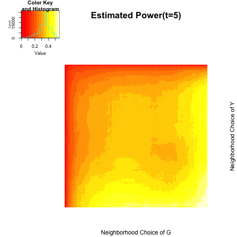

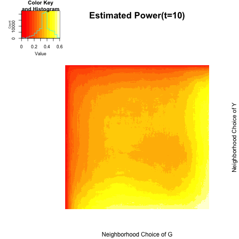

|  | t=1 | t=2 | t=5 | t=10 |
| --- | --- | --- | --- | --- |
| global test | 0.254 | 0.446 | 0.548 | 0.590 |
| local optimal | 0.360 | 0.496 | 0.560 | 0.602 |

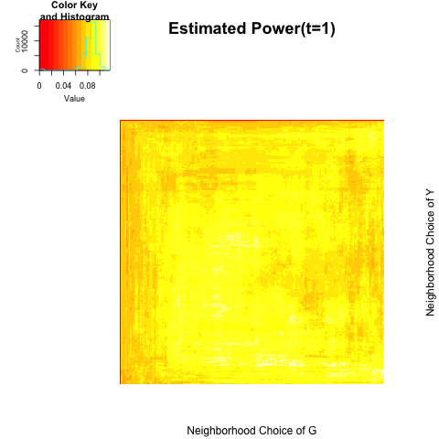

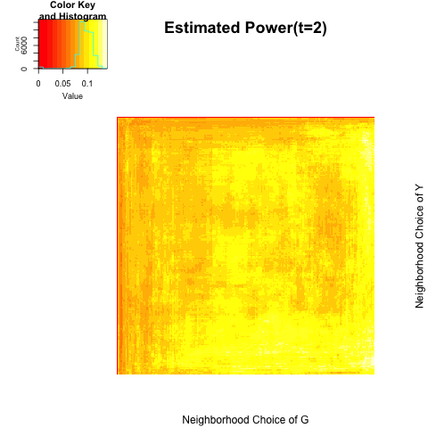

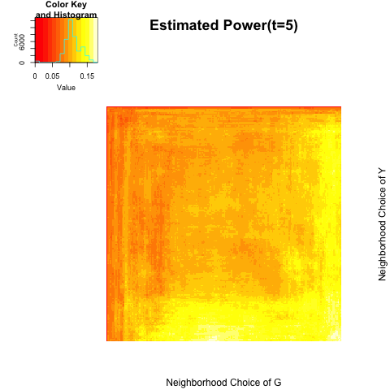

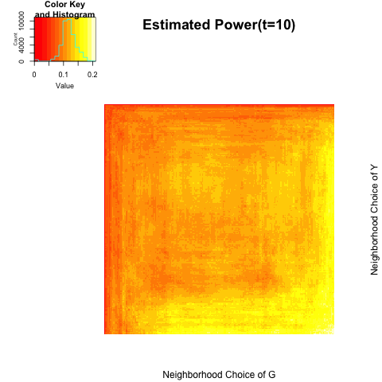

|  | t=1 | t=2 | t=5 | t=10 |
| --- | --- | --- | --- | --- |
| global test | 0.1000 | 0.1133 | 0.1633 | 0.21 |
| local optimal | 0.1167 | 0.1400 | 0.1800 | 0.21 |

5. $B = 2;$ $\rho = (0.2, 0.0)$ ; ratio = (1,3); $n = 300$ ; $M = 300$;

Only 25$\%$ of observations are dependent on their underlying network structures.

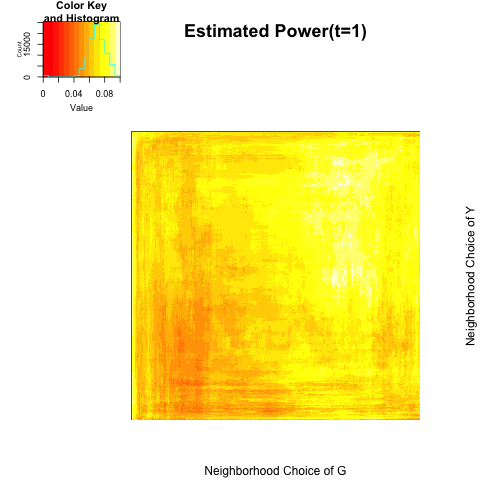

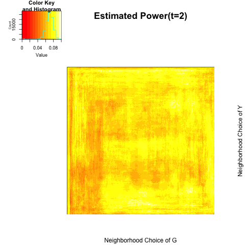

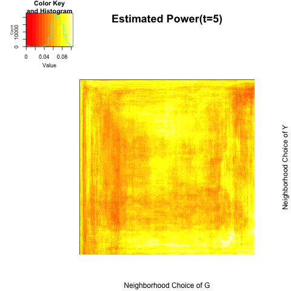

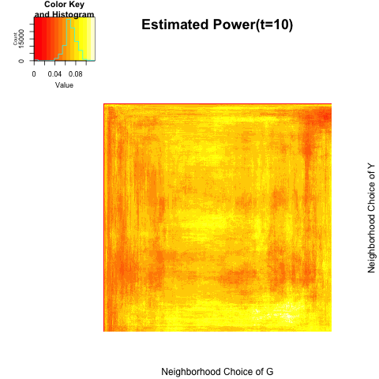

|  | t=1 | t=2 | t=5 | t=10 |
| --- | --- | --- | --- | --- |
| global test | 0.0533 | 0.0567 | 0.0800 | 0.0933 |
| local optimal | 0.1000 | 0.1000 | 0.1033 | 0.1167 |

6. $B = 2;$ $\rho = (0.5, 0.0)$ ; ratio = (1,3); $n = 300$ ; $M = 300$;

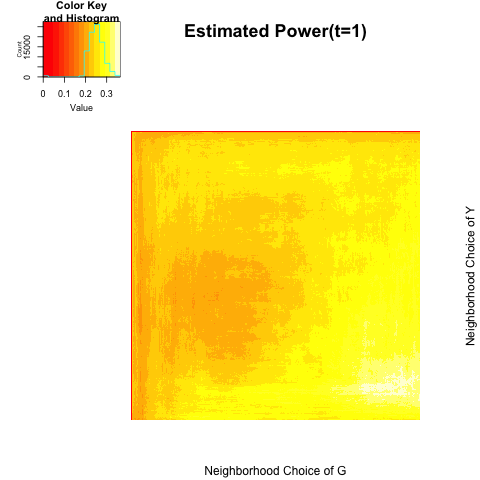

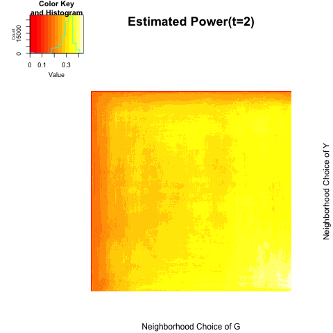

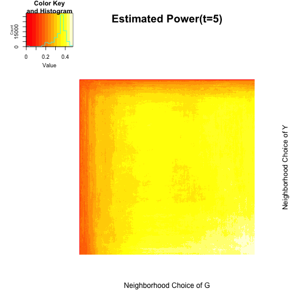

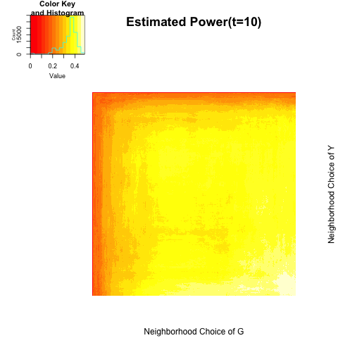

|  | t=1 | t=2 | t=5 | t=10 |
| --- | --- | --- | --- | --- |
| global test | 0.2600 | 0.3833 | 0.4633 | 0.4767 |
| local optimal | 0.3633 | 0.4400 | 0.4767 | 0.4867 |